# Text analysis of news headlines.

### Common Libraries

```r
# plotting and pipes
library(ggplot2)
library(dplyr, warn.conflicts = FALSE)
options(dplyr.summarise.inform = FALSE)

# text mining library
suppressPackageStartupMessages(library(tidyverse))
library(tm)
library(tidytext)

# date/time libaray
library(lubridate, warn.conflicts = FALSE)

# stemming libary
library(SnowballC)
```

### NER (Named-entity recognition)

A subtask of IE (information extraction) that identifies and classifies named entities mentioned in unstructured text into pre-defined categories such as person names, organizations, locations, time, quantities, monetary values, etc.

#### Use Cases of Named Entity Recognition

- Classifying Content: For example, automating online content for articles by tagging the major people, organizations, and places discussed. This enables automated categorization of articles in defined hierarchies to help with content discovery
- Efficient Search Algorithms: For online publisher, NER be run once on all documents and the relevant entities (tags) associated with each are stored separately. This could speed up the search process as a search term will be matched with the smaller list of entities for each article.
- Content Recommendations: In online publishing, NER can be used to recommend similar articles by extracting entities from a particular document and recommending the others that have the most similar entities mentioned.
- Customer Support: NER can be used for handling the online customer support by scanning through the mentions in your customers’ feedback. With NER named entities including location and product can be pulled out, then then used to categorize the complaint and assign it to the relevant department for handling.

### spacyr

provides an R wrapper around the Python spaCy package. It offers easy access to the following functionality of spaCy:

- parsing texts into tokens or sentences
- lemmatizing tokens
- parsing dependencies (to identify the grammatical structure of the sentence)
- identifying, extracting, or consolidating token sequences that form named entities or noun phrases

It also allows a user to request additional token-level attributes directly from spaCy. spacyr also takes care of the installation of not only spaCy but also Python itself, in a self-contained miniconda or virtualenv environment, and can install additional language models or upgrade spaCy as new models and versions become available.

```r
library("spacyr")
spacy_initialize(model = "en_core_web_sm")
```

### Read and transform data

```r
# read as a tibble
df = read.csv('./data/news_headlines.csv', stringsAsFactors = FALSE)

# remove duplicates
df = df[!duplicated(df$headline),]

# Transformations
df$publish_date = as.Date(df$publish_date, "%m/%d/%y")

df$publish_year = lubridate::year(df$publish_date)
df$publish_mon = lubridate::month(df$publish_date, label = TRUE, abbr = TRUE)

df = df %>%
  mutate(headline_len = str_count(headline))

df = df %>%
  filter(headline_len >= 6)  # remove short headlines

df %>%
  filter(headline_len >= 10)  %>% # headline length > 10 chars
  select(-publish_year, -publish_mon, -headline_len) %>%
  head()
```

```
## # A tibble: 6 x 2
##   publish_date headline
##   <date>       <chr>
## 1 2009-01-01   2008 deadliest year for us forces in afghanistan
## 2 2009-01-01   2008 dubbed wet year for hunter
## 3 2009-01-01   2 israelis injured in danish mall shooting
## 4 2009-01-01   8500 qld homes without power after storms
## 5 2009-01-01   about 60 killed in bankgok fire
## 6 2009-01-01   act govt bodies forced to comply with human rights
```

### number of headlines by year

```r
 df %>%
  group_by(publish_year) %>%
  summarise( n = n()) %>%
  arrange(-n)
```

```
## # A tibble: 11 x 2
##    publish_year     n
##           <dbl> <int>
##  1         2013 87665
##  2         2012 83328
##  3         2014 78513
##  4         2015 75514
##  5         2009 75120
##  6         2011 74547
##  7         2010 72373
##  8         2016 60737
##  9         2017 46828
## 10         2018 39372
## 11         2019 32966
```

### tidying data

```r
# convert dataframe to tibble
tidy_df <- as_tibble(df$headline)

# the text is itself a dataframe? modify the text column to pull out the text value
tidy_df <- tidy_df %>%
  mutate(text =  tidy_df$value)  %>%
  select(-value)

# sample docs
set.seed(1234)
tidy_df = tidy_df  %>%
  sample_n(2000)
```

### Named entity recognition with spaCy

- https://cran.r-project.org/web/packages/spacyr/vignettes/using_spacyr.html

```r
# convert to TIF standard required by spacy
tidy_df = tidy_df %>%
  mutate(doc_id = paste0("doc", row_number())) %>%
  select(doc_id, everything())
tidy_df
```

```
## # A tibble: 2,000 x 2
##    doc_id text
##    <chr>  <chr>
##  1 doc1   best running shoe for you depends on your weight research finds
##  2 doc2   no rain respite for far north qld fires
##  3 doc3   turnbull praises rudd's vision; baffled over leadership
##  4 doc4   police bullet killed drug raid officer
##  5 doc5   hundreds the war dead at ceremonies around
##  6 doc6   riverina rice harvest
##  7 doc7   abattoir proposed david cox
##  8 doc8   williamtown priority must be military baldwin
##  9 doc9   grower wins award to help put eels in the rice
## 10 doc10  retirement village angst
## # … with 1,990 more rows
```

```r
# parse name-entities
parsedtxt <- spacy_parse(tidy_df, type = "all")

ner = entity_extract(parsedtxt)  %>%
  arrange(entity_type)
ner
```

```
## # A tibble: 1,299 x 4
##    doc_id  sentence_id entity                       entity_type
##    <chr>         <int> <chr>                        <chr>
##  1 doc17             1 black_saturday               EVENT
##  2 doc273            1 world_science_festival       EVENT
##  3 doc449            1 the_great_war                EVENT
##  4 doc1066           1 world_cup                    EVENT
##  5 doc1374           1 world_cup                    EVENT
##  6 doc1389           1 world_cup                    EVENT
##  7 doc1741           1 olympics                     EVENT
##  8 doc45             1 379th                        FAC
##  9 doc423            1 fairfield_road_rage_incident FAC
## 10 doc474            1 newcastle_refugee_centre     FAC
## # … with 1,289 more rows
```

- Entities of type PERSON which are People, including fictional.
- Entities of type NORP which are Nationalities or religious or political groups.
- Entities of type ORG which are Companies, agencies, institutions, etc.
- Entities of type GPE which are geo-political entities such as city, state/province, and country
- Entities of type PRODUCT which are products

```r
entities<- c("PERSON", "NORP", "ORG", "GPE", "PRODUCT")

for (e in entities){
  ner %>%
    mutate(type=e) %>%
    filter(entity_type == e) %>%
    group_by(entity, type) %>%
    summarize(count = n()) %>%
    arrange(desc(count)) %>%
    print()

}
```

```
## # A tibble: 396 x 3
## # Groups:   entity [396]
##    entity          type   count
##    <chr>           <chr>  <int>
##  1 donald_trump    PERSON     6
##  2 darwin          PERSON     5
##  3 barnett         PERSON     3
##  4 bush            PERSON     3
##  5 nick_kyrgios    PERSON     3
##  6 bob_day         PERSON     2
##  7 boris_johnson   PERSON     2
##  8 colin_barnett   PERSON     2
##  9 donald          PERSON     2
## 10 hillary_clinton PERSON     2
## # … with 386 more rows
## # A tibble: 53 x 3
## # Groups:   entity [53]
##    entity      type  count
##    <chr>       <chr> <int>
##  1 australian  NORP     18
##  2 chinese     NORP      6
##  3 greens      NORP      5
##  4 russian     NORP      5
##  5 tasmanian   NORP      5
##  6 australians NORP      3
##  7 evans       NORP      3
##  8 french      NORP      3
##  9 german      NORP      3
## 10 indian      NORP      3
## # … with 43 more rows
## # A tibble: 377 x 3
## # Groups:   entity [377]
##    entity type  count
##    <chr>  <chr> <int>
##  1 govt   ORG       7
##  2 nsw    ORG       5
##  3 perth  ORG       4
##  4 un     ORG       4
##  5 epa    ORG       3
##  6 eu     ORG       3
```

[output cut: 10 more lines]

```
##  2 china       GPE      19
##  3 us          GPE       9
##  4 new_zealand GPE       7
##  5 canberra    GPE       6
##  6 tasmania    GPE       6
##  7 fiji        GPE       5
##  8 india       GPE       5
##  9 indonesia   GPE       5
## 10 paris       GPE       5
## # … with 130 more rows
## # A tibble: 1 x 3
## # Groups:   entity [1]
##   entity            type    count
##   <chr>             <chr>   <int>
## 1 san_marino_motogp PRODUCT     1
```

### Topic Modeling

Topic modeling is an unsupervised, technique for classification of text data into natural groups or topics. With topic modeling, large sets of documents (eg: blogs, news articles, etc.) are scanned in order to detect word or phrase patterns and to automatically cluster them into word groups that best characterizes the set of documents. It is unsupervised in that the text data is unlabeled and there is no training. Generally, the criteria for classification is unknown in advance. Topic modelling helps with the following:

- Discovery of hidden topical patterns present across the collection of documents
- Annotating documents according to these topics
- Using these annotations to organize, search and summarize texts

In business, topic modeling can be used for - discovering hidden topics in customer feedback to help organizations focus the most severe customer issues - summarizing text in journals to enable users to recall content more efficiently. - building a recommendation system. There are many techniques that are used to obtain topic models, namely: Latent Dirichlet Allocation (LDA), Latent Semantic Analysis (LSA), Correlated Topic Models (CTM), and TextRank.

### Latent Dirichlet Allocation (LDA)

Is an unsupervised classification method designed for text data. Rather than relying on labeled (eg: hand-coded data sets), it is a probabilistic topic model that uses statistical algorithms to analyze words in raw text documents, to uncover thematic structure of the both the corpus and individual documents. To use it requires: - A document-term matrix - The number of topics you would like the algorithm to pick up.

LDA treats each document as a mixture of topics, and each topic as a mixture of words. This allows documents to overlap each other in terms of content, rather than being separated into discrete groups. Only the documents and words can be observed, not the topics whose structure is hidden (eg: latent). Hence LDA seeks to infer topic structure given known words and documents.  
For example, given the following set of documents in a corpus:

- Doc 1: I ate a peanut butter sandwich for breakfast.
- Doc 2: I like to eat almonds, peanuts and walnuts.
- Doc 3: My neighbor got a little dog yesterday.
- Doc 4: Cats and dogs are mortal enemies.
- Doc 5: You must not feed peanuts to your dog.

The LDA model discovers the different topics that the documents represent and how much of each topic is present in a document. For the above, LDA may produce the following results:

Topic 1: 30% peanuts, 15% almonds, 10% breakfast, which can be interpreted as a food topic.  
Topic 2: 20% dogs, 10% cats, 5% peanuts, which can be interpreted as a topic dealing with pets/animals.

- Doc 1 and Doc 2: 100% Topic 1
- Doc 3 and Doc 4: 100% Topic 2
- Doc 5: 70% Topic 1, 30% Topic 2

### preprocessing

In this case, I will look at a sample of 1000 documents from 2019

```r
library(topicmodels)
library(textstem)

# sample smaller set of docs
set.seed(1234)
cdf = df %>%
  filter(publish_year == 2019)  %>%
  sample_n(1000)


hlCorpus <- Corpus(VectorSource(cdf$headline))

hlCorpus <- tm_map(hlCorpus, removePunctuation)  # remove punctuation
hlCorpus <- tm_map(hlCorpus, removeNumbers)      # remove numbers
hlCorpus <- tm_map(hlCorpus, stripWhitespace)    # remove white space

# stop and custom stop
hlCorpus <- tm_map(hlCorpus, removeWords, c(stopwords('english')))

hlCorpus <- tm_map(hlCorpus, lemmatize_strings) # lemmatizaton
#hlCorpus <- tm_map(hlCorpus, stemDocument)  #stem words using SnowBall stemmer


hlCorpus <- tm_map(hlCorpus, removeWords, c( 'says', 'will', 'can',
                'talk', 'tell', 'begin', 'one', 'two', 'first', 'say', 'take', 'get',
                'may', 'not', 'new', 'make', 'back', 'see', 'use',  'australia',
                'australian', 'change'))

# doc matrix
# for b-grams
#BigramTokenizer <- function(x)
#    unlist(lapply(ngrams(words(x), 2), paste, collapse = " "), use.names = FALSE)
#dtm <- DocumentTermMatrix(hlCorpus, control = list(minWordLength=5, tokenize = BigramTokenizer))

dtm <- DocumentTermMatrix(hlCorpus, control = list(minWordLength = 5,
                removeNumbers=FALSE, removePunctuation=FALSE,
                removeStopwords=FALSE,  stemWords=FALSE, stripWhitespace=FALSE))

#dtm = removeSparseTerms(dtm, 0.998)
inspect(dtm)
```

```
## <<DocumentTermMatrix (documents: 1000, terms: 2977)>>
## Non-/sparse entries: 5966/2971034
## Sparsity           : 100%
## Maximal term length: 17
## Weighting          : term frequency (tf)
## Sample             :
##      Terms
## Docs  attack death fire house man nsw police queensland trump win
##   20       0     0    0     0   0   0      0          0     0   0
##   26       0     0    0     0   0   0      0          0     0   0
##   312      0     0    0     0   0   0      0          0     0   0
##   36       0     0    0     0   0   0      0          0     0   0
##   381      0     0    0     0   0   0      0          0     0   0
##   39       0     0    0     0   0   0      0          0     0   0
##   51       1     0    0     0   0   0      0          0     0   0
##   833      0     0    0     0   0   0      0          0     0   0
##   85       1     0    0     0   0   0      0          0     0   0
##   88       0     0    0     0   0   0      0          0     0   0
```

```r
# View(as.matrix(dtm))
```

If you use removeSparseTerm for vocabulary pruning, you may have empty rows in the dtm. LDA does not like this, so we must remove those docs from the dtm.

```r
# check for rows with all 0's
zero_row <- cdf[rowSums(as.matrix(dtm)) == 0, ]
dim(zero_row)
```

```
## [1] 0 5
```

```r
# if the above returns greater than 0 then perform the following to remove
sel_idx <- rowSums(as.matrix(dtm)) > 0
dtm <- dtm[sel_idx, ]
dim(dtm)
```

```
## [1] 1000 2977
```

In this case, there were no rows which contained all 0’s hence there was no change in the number of terms

### inspect first 10 documents in the corpus

```r
inspect(hlCorpus[1:10])
```

```
## <<SimpleCorpus>>
## Metadata:  corpus specific: 1, document level (indexed): 0
## Content:  documents: 10
##
##  [1] flame oil tanker gulf oman
##  [2] perth modern school rank 2  socio advantage
##  [3] stephen long speak business
##  [4] search miss people torres strait empty boat find
##  [5] chinese fashion brand advertisment controversy
##  [6] major european nation recognise venezuelas guaido
##  [7] medieval re enactment group grow popularity
##  [8] philip lowe rba prod government stimulate economy
##  [9] aftermath marthavale fire scorch bushland home
## [10] white island recovery mission press conference
```

### find the best k

Recall that LDA requires that we supply the number of topics (K). If you have prior knowledge on the topic structure, this can be used to inform your selection of a reasonable value for K. Too few could result in groupings of unrelated content while too large could risk being overly granular with the topic categories. There are several statistical measures that can help in finding an optimal value for K.  
Perplexity is one and is used to measure how well a probability model predicts a sample. As applied to LDA, for a given value of K, one can estimate the LDA model by comparing perplexity across different models with varying k’s. The model with the lowest perplexity is generally considered the best.

I’ve chosen to look at models with K up to 11 topics. The min number is always 2 and you will need to experiment to determine the top threshold. Here’s I’ve chosen 11 ffor a total of 10 models to review.

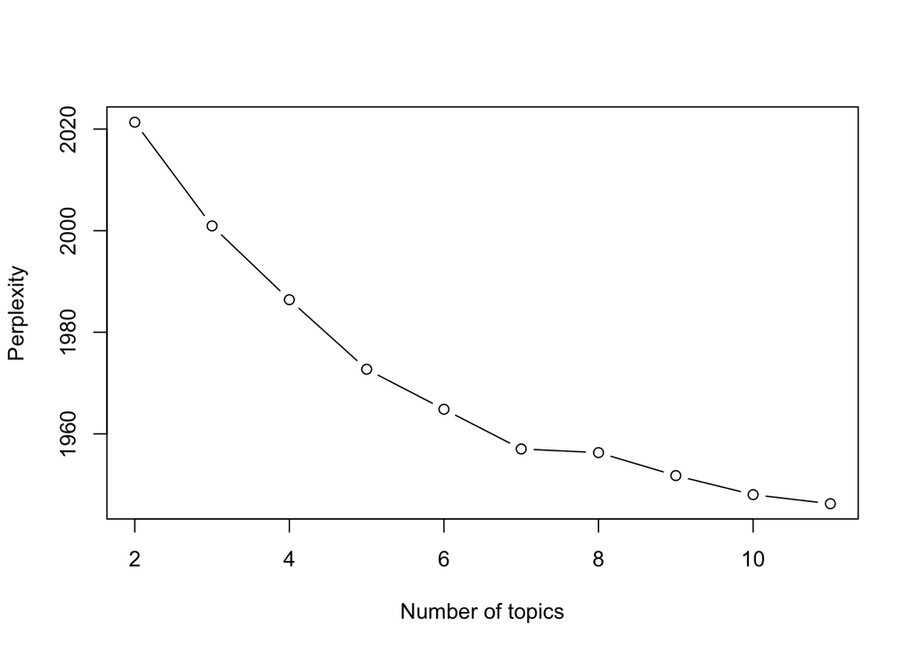

```r
#mod_log_lik = numeric(0)
mod_perplexity = numeric(0)
topics <- c(2:11)

for (i in topics){
  mod <- LDA(dtm, k = i, method = "Gibbs",
             control = list(seed=1234) ) # random seed for consitent results between runs
  #mod_log_lik[i] = logLik(mod)
  mod_perplexity[i] = perplexity(mod, dtm)
}
mod_perplexity <- mod_perplexity[!is.na (mod_perplexity)] # remove NA at first position

# plot
plot(x=topics, y=mod_perplexity, type = "b", xlab = "Number of topics", ylab = "Perplexity")
```

Looks like k of 11 is the best given the lowest perplexity

### per-term-per-topic matrix

```r
hl_lda <- LDA(dtm, k = 11, control = list(seed = 1234))
hl_lda
```

```
## A LDA_VEM topic model with 11 topics.
```

```r
# beta (per-term-per-topic)
hl_topics <- tidy(hl_lda, matrix = "beta")
hl_topics %>%
  arrange(term, -beta)  %>%
  head()
```

```
## # A tibble: 6 x 3
##   topic term       beta
##   <int> <chr>     <dbl>
## 1     1 aaco  1.91e-  3
## 2     9 aaco  6.36e- 29
## 3     8 aaco  4.51e-319
## 4     3 aaco  6.58e-320
## 5     7 aaco  6.47e-320
## 6     6 aaco  3.29e-320
```

Observe that words can be associated with more than one topic. For each combination, the model computes the probability (beta) of that term being generated from that topic. Here we see that aaco is more likely to be assigned to topic 1

### per-document-per-topic

```r
tidy(hl_lda, matrix = "gamma")  %>%
  arrange(document, -gamma)  %>%
  head()
```

```
## # A tibble: 6 x 3
##   document topic   gamma
##   <chr>    <int>   <dbl>
## 1 1            7 0.918
## 2 1            8 0.00824
## 3 1            2 0.00824
## 4 1           10 0.00824
## 5 1            1 0.00824
## 6 1            3 0.00824
```

Just as words can be associated with more than one topic, documents can be associated with more than one topic. Here we see that document 1 is more likely to be assigned to topic 7.

### Show the 10 terms that are most common within each topic.

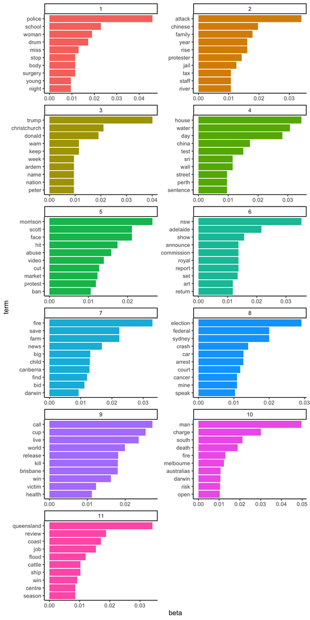

```r
hl_top_terms <- hl_topics %>%
  group_by(topic) %>%
  top_n(10, beta) %>%
  ungroup() %>%
  arrange(topic, -beta)

hl_top_terms %>%
  mutate(term = reorder_within(term, beta, topic)) %>%
  ggplot(aes(beta, term, fill = factor(topic))) +
    geom_col(show.legend = FALSE) +
    facet_wrap(~ topic, scales = "free", ncol=2) +
    theme_classic(base_size = 16) +
    scale_y_reordered()
```

Having domain knowledge would allow one to better assess whether or not the topics makes sense, that is being familiar with the news headline in Australia for 2019. It is also possible that the model did not do a good job in categorizing the topics as some words do not appear related so more granularity may be in order, such as increasing the number of topics.